# Coding Resources

Part of the CBCS Coding Club’s initiative is to compile a list of different coding resources that could support environmental and conservation research. This compilation is ‘alive’, and so if there are any resources that you think are missing from the list below (we know that we are missing lots!), please do contact any of the current coding club leads and we can add them.

# Databases

Conservation and environmental researchers often use the same open-access data. Here are some of the databases that are often used in these research fields, some of which can be accessed directly through programming packages.

[figure not shown]

[**IUCN Red List**](https://www.iucnredlist.org/)

There are lots of different R packages that can be used to access the [IUCN Red List’s data repository](https://www.iucnredlist.org/resources/data-repository).

- [`iucnredList`](https://iucn-uk.github.io/iucnredlist/)
- [`rredlist`](https://cran.r-project.org/web/packages/rredlist/vignettes/rredlist.html)
- [`iucnr`](https://cran.r-project.org/web/packages/iucnr/index.html)
- [`red`](https://bdj.pensoft.net/article/20530/)

[figure not shown]

[**World Database on Protected Areas (WDPA)**](https://www.protectedplanet.net/en/thematic-areas/wdpa?tab=WDPA)

- [`wdpar`](https://cran.r-project.org/web/packages/wdpar/vignettes/wdpar.html)

[figure not shown]

[**Australia’s Terrestrial Ecosystem Network (TERN)**](https://www.tern.org.au/)

Explore TERN’s [data portals and services](https://www.tern.org.au/environmental-data-service/).

- [`ausplotsR`](https://github.com/ternaustralia/ausplotsR)
- [`WildObsR`](https://wildobs.org.au/): not yet publicly available, but stay tuned!

[figure not shown]

[**Marine Regions**](https://www.marineregions.org/) of the world

Get the the boundaries and shapefiles you need for exclusive economic zones (EEZ), areas beyond national jurisdiction, global oceans and seas, large marine ecosystems of the world (MEOW), Longhurst provinces, and many more!

- [`mregions2`](https://github.com/ropensci/mregions2)

[figure not shown]

A collection of different climate data products from the [**Coupled Model Intercomparison Project 6 (CMIP6)**](https://wcrp-cmip.org/cmip-phases/cmip6/)

Here are some R packages that could help wrangle climate outputs.

- [`hotrstuff`](https://snbuenafe.github.io/hotrstuff/): R package in development led by Tin Buenafe
- [`rcdo`](https://cran.r-project.org/web/packages/rcdo/index.html)

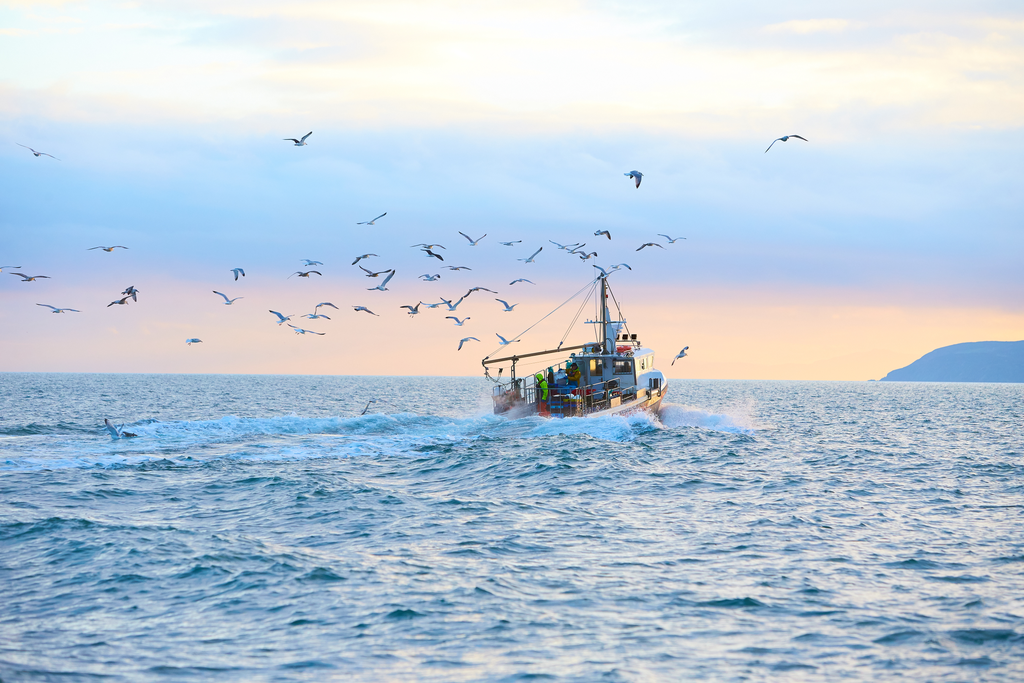

A collection of different fisheries-related products

- [Global Fishing Watch](https://globalfishingwatch.org/)
  - [`gfwr`](https://github.com/GlobalFishingWatch/gfwr) is an R package for accessing the GFW data through an API (application programming interface) key
- `FishStatJ` to access FAO (Food and Agriculture Organization of the United Nations)’s Fisheries and Aquaculture statistics
- [`ARTIS`](https://artisdata.weebly.com/) is a database that provides the first global estimates of seafood species and nutrient trade flows

The [Global Biodiversity Information Facility (GBIF)](https://www.gbif.org/)

- [`galah`](https://galah.ala.org.au/R/) is an R package used to access GBIF and the [Atlas of Living Australia (ALA)](https://www.ala.org.au/)

# Packages

These are some of the most common packages used in a lot of analysis in conservation and environmental research.

- [`rnaturalearth`](https://cran.r-project.org/web/packages/rnaturalearth/vignettes/rnaturalearth.html) to access natural earth vector map data (e.g., administrative boundaries and borders of countries, coastlines). Some key functions include:
  - `ne_countries()`
  - `ne_download()`
- [`countrycode`](https://cran.r-project.org/web/packages/countrycode/index.html) for standardizing country names

In terms of analysis, here are some R packages that are useful for data wrangling, analysis and visualization.

## Data wrangling and analysis

- [`janitor`](https://cran.r-project.org/web/packages/janitor/index.html) for cleaning up messy data
- [`here`](https://here.r-lib.org/) for setting working directories
- [`purrr`](https://purrr.tidyverse.org/) for functional programming in loops made easy!
- [`furrr`](https://furrr.futureverse.org/) combining `purrr` with `future`’s parallel capabilities

## Spatial wrangling and analysis

- [`terra`](https://rspatial.github.io/terra/) for wrangling and analyzing raster (and vector!) data
- [`sf`](https://r-spatial.github.io/sf/) for wrangling and analyzing vector data

## Visualization

- [`ggplot2`](https://ggplot2.tidyverse.org/) for all-around visualizations, and great for visualizing `sf` objects using primarily `geom_sf()`
- [`tmap`](https://r-graph-gallery.com/package/tmap.html) for thematic mapping
- [`leaflet`](https://r-graph-gallery.com/package/leaflet.html) for creating interactive maps
- [`tidyterra`](https://dieghernan.github.io/tidyterra/) for visualizing `terra` objects using `ggplot2`
- [`patchwork`](https://patchwork.data-imaginist.com/) for stitching together different plots

# Online books

If you’re the type to learn more by reading textbooks, here are some great online textbooks that you can read.

- [R for Data Science (2e)](https://r4ds.hadley.nz/)
- [Advance R](https://adv-r.hadley.nz/)
- [Mastering Shiny](https://mastering-shiny.org/)

# Websites and online resource hubs

There are thousands of different packages in different programming languages, and sometimes, the package just doesn’t have great documentation. Fear not! There are some websites and online resource hubs that dive deep into some of these packages and their different functions.

- [R Graph Gallery](https://r-graph-gallery.com/)
  - [R Graph Gallery Book](https://bookdown.org/content/b298e479-b1ab-49fa-b83d-a57c2b034d49/)
- [Posit Cheatsheets](https://posit.co/resources/cheatsheets/)
  - [`tidyr` Cheatsheet](https://rstudio.github.io/cheatsheets/html/tidyr.html)
  - [`dplyr` Cheatsheet](https://rstudio.github.io/cheatsheets/html/data-transformation.html)
  - [`ggplot2` Cheatsheet](https://rstudio.github.io/cheatsheets/html/data-visualization.html)
  - [`stringr` Cheatsheet](https://rstudio.github.io/cheatsheets/html/strings.html)
  - [`purrr` Cheatsheet](https://rstudio.github.io/cheatsheets/html/purrr.html)
  - [Quarto Cheatsheet](https://rstudio.github.io/cheatsheets/html/quarto.html)
  - [`arrow` for R](https://rstudio.github.io/cheatsheets/arrow.pdf)
- [Coloring in R’s Blind Spot](https://journal.r-project.org/articles/RJ-2023-071/)
- [Collection of different color palettes](https://github.com/EmilHvitfeldt/r-color-palettes?tab=readme-ov-file)